# EP11 - Regresión Lineal Logística

Equipo 4

2025-06-19

## 1. Definir la semilla a utilizar, que corresponde a los primeros cinco dígitos del RUN del integrante de mayor edad del equipo.

```r
# 1. Definir semilla
set.seed(21226)

# Lectura de datos
datos <- read.csv2("EP09 Datos.csv", sep = ";")
columnas <- colnames(datos)

# Creacion variable IMC
datos$IMC <- datos$Weight / ((datos$Height / 100) **2)

# Crear variable EN (1 si IMC >= 23,2)
datos$EN <- ifelse((datos$IMC >= 23.2), 1, 0)

# Conseguir muestra de 100 personas separadas segun EN (50 y 50).
muestra1 <- datos %>%
  filter(EN == 1) %>%
  sample_n(50)

muestra2 <- datos %>%
  filter(EN == 0) %>%
  sample_n(50)

muestra <- rbind(muestra1, muestra2)
```

## 2. Seleccionar una muestra de 100 personas, asegurando que la mitad tenga estado nutricional “sobrepeso” y la otra mitad “no sobrepeso”.

```r
# Conseguir muestra de 100 personas separadas segun EN (50 y 50).
muestra1 <- datos %>%
  filter(EN == 1) %>%
  sample_n(50)

muestra2 <- datos %>%
  filter(EN == 0) %>%
  sample_n(50)

muestra <- rbind(muestra1, muestra2)
muestra <- muestra[sample(1:nrow(muestra)),] # mezclar filas
```

## 3. Usando las herramientas del paquete leaps, realizar una búsqueda exhaustiva para seleccionar entre dos y ocho predictores que ayuden a estimar la variable Peso (Weight), obviamente sin considerar las nuevas variables IMC ni EN, y luego utilizar las funciones del paquete caret para construir un modelo de regresión lineal múltiple con los predictores escogidos y evaluarlo usando bootstrapping.

```r
# Busqueda Exhaustiva
busqueda <- regsubsets(Weight ~., method = "exhaustive", nbest = 2, nvmax = 8, data = muestra,
                       force.out = c("IMC", "EN"))

# extraer resultados, modelo con menor BIC en este caso
resumen_busqueda <- summary(busqueda)
i_bic_minimo <- which.min(resumen_busqueda$bic)
mejor_bic <- resumen_busqueda$which[i_bic_minimo, ]
variables_mejor_bic <- names(mejor_bic[mejor_bic == TRUE])[-1] # -1 para quitar "(Intercept)"
print(variables_mejor_bic)
```

```
## [1] "Chest.depth"        "Chest.diameter"     "Elbows.diameter"
## [4] "Waist.Girth"        "Thigh.Girth"        "Forearm.Girth"
## [7] "Calf.Maximum.Girth" "Height"
```

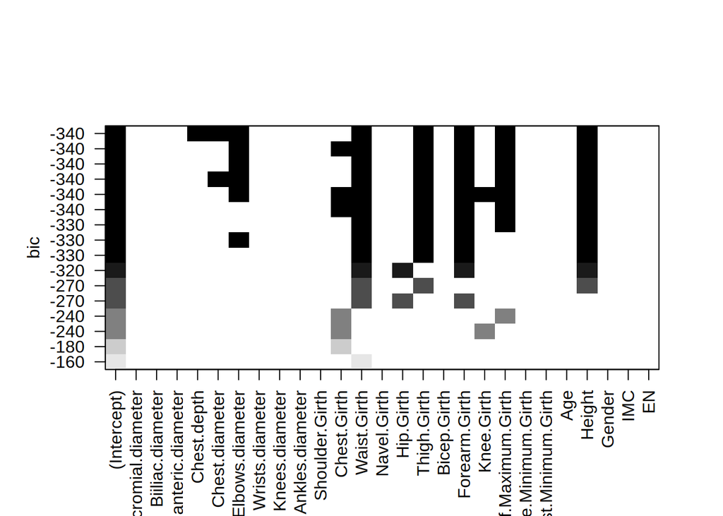

```r
plot(busqueda)
```

Creacion de modelo de regresión lineal múltiple con los predictores seleccionados:

```r
#Construcción del modelo con bootstrapping
control <- trainControl(method = "boot", number = 2999)
modelo_lm <- train(Weight ~ .,
                  data = muestra[, c("Weight", variables_mejor_bic)],
                  method = "lm",
                  trControl = control)

#Análisis detallado del modelo final
cat("\nResumen del modelo final:\n")
```

```
##
## Resumen del modelo final:
```

```r
print(summary(modelo_lm$finalModel))
```

```
##
## Call:
## lm(formula = .outcome ~ ., data = dat)
##
## Residuals:
##     Min      1Q  Median      3Q     Max
## -3.8741 -1.3846  0.0583  1.2945  5.5598
##
## Coefficients:
##                      Estimate Std. Error t value Pr(>|t|)
## (Intercept)        -104.66623    4.82001 -21.715  < 2e-16 ***
## Chest.depth           0.29207    0.13038   2.240 0.027519 *
## Chest.diameter        0.37206    0.15170   2.453 0.016092 *
## Elbows.diameter       0.87929    0.34614   2.540 0.012770 *
## Waist.Girth           0.46310    0.03853  12.019  < 2e-16 ***
## Thigh.Girth           0.50542    0.05807   8.704 1.31e-13 ***
## Forearm.Girth         0.67146    0.17927   3.745 0.000315 ***
## Calf.Maximum.Girth    0.50269    0.14030   3.583 0.000548 ***
## Height                0.26924    0.03452   7.800 9.94e-12 ***
## ---
## Signif. codes:  0 '***' 0.001 '**' 0.01 '*' 0.05 '.' 0.1 ' ' 1
##
## Residual standard error: 2.04 on 91 degrees of freedom
## Multiple R-squared:  0.9778, Adjusted R-squared:  0.9759
## F-statistic: 501.4 on 8 and 91 DF,  p-value: < 2.2e-16
```

```r
#Métricas de evaluación
cat("\nMétricas de evaluación del modelo:\n")
```

```
##
## Métricas de evaluación del modelo:
```

```r
print(modelo_lm$results)
```

```
##   intercept     RMSE  Rsquared      MAE    RMSESD  RsquaredSD     MAESD
## 1      TRUE 2.248295 0.9712364 1.792221 0.2359693 0.007819955 0.1935911
```

```r
#Importancia relativa de las variables
importancia <- varImp(modelo_lm)
print(importancia)
```

```
## lm variable importance
##
##                    Overall
## Waist.Girth        100.000
## Thigh.Girth         66.097
## Height              56.849
## Forearm.Girth       15.393
## Calf.Maximum.Girth  13.732
## Elbows.diameter      3.070
## Chest.diameter       2.172
## Chest.depth          0.000
```

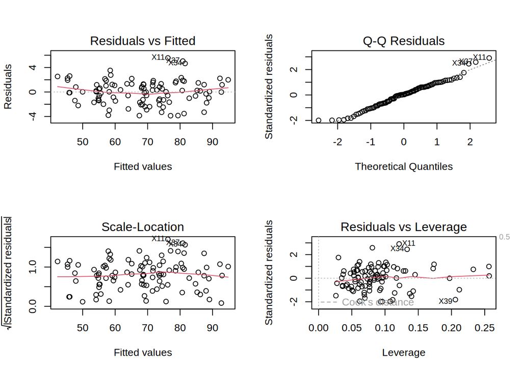

```r
#Diagnósticos del modelo
par(mfrow=c(2,2))
plot(modelo_lm$finalModel)
```

El análisis de los coeficientes muestra que todos los predictores son significativos, ya que todos tienen p-valor < 0.05. esto indica que cada uno de los predictores seleccionados contribuye significativamente al modelo de regresión lineal múltiple.

ahora pasaremos a estudiar los diagnósticos de residuos, que son cruciales para verificar los supuestos del modelo de regresión lineal múltiple.

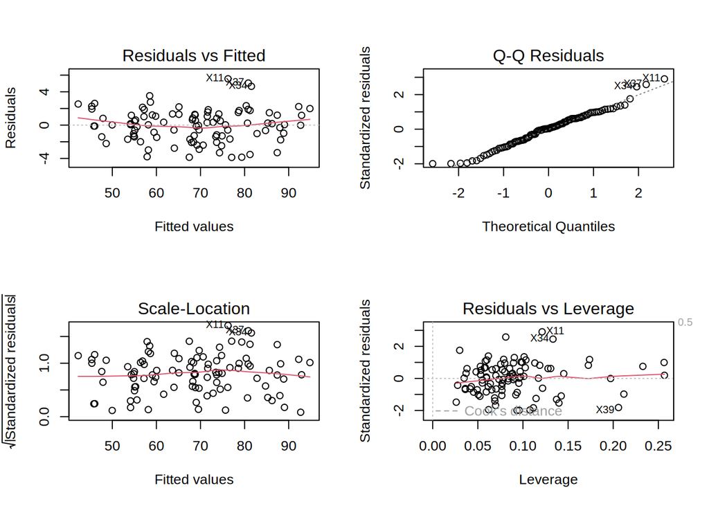

```r
# Extraer los residuos del modelo
residuos <- residuals(modelo_lm$finalModel)
valores_ajustados <- fitted(modelo_lm$finalModel)

par(mfrow=c(2,2))
plot(modelo_lm$finalModel)
```

```r
par(mfrow=c(1,1))
```

Segun lo visto en los gráficos de diagnóstico, podemos observar que los residuos parecen tener una distribución normal, lo que sugiere que el supuesto de normalidad de los residuos se cumple.

Estudiando la confiabilidad del modelo, es importante realizar pruebas formales de los supuestos de la regresión lineal múltiple, como la normalidad de los residuos, homocedasticidad, independencia de los residuos y multicolinealidad.

```r
# Normalidad de los Residuos:
# H0: Los residuos siguen una distribución normal.
# Ha: Los residuos no siguen una distribución normal.

cat("\n--- Prueba de Normalidad de los Residuos (Shapiro-Wilk) ---\n")
```

```
##
## --- Prueba de Normalidad de los Residuos (Shapiro-Wilk) ---
```

```r
shapiro_test <- shapiro.test(residuos)
print(shapiro_test)
```

```
##
##  Shapiro-Wilk normality test
##
## data:  residuos
## W = 0.98276, p-value = 0.2167
```

```r
# Homocedasticidad con ncvTest:
cat("\n--- Prueba de Homocedasticidad (Breusch-Pagan) ---\n")
```

```
##
## --- Prueba de Homocedasticidad (Breusch-Pagan) ---
```

```r
ncv <- ncvTest(modelo_lm$finalModel)
print(ncv)
```

```
## Non-constant Variance Score Test
## Variance formula: ~ fitted.values
## Chisquare = 1.420516, Df = 1, p = 0.23332
```

Seguiremos estudiando las demas conclusiones

```r
# Independencia de los Residuos
# H0: Los residuos son independientes.
# Ha: Los residuos están autocorrelacionados.
dw_test <- durbinWatsonTest(modelo_lm$finalModel)
print(dw_test)
```

```
##  lag Autocorrelation D-W Statistic p-value
##    1      -0.1090894      2.209909   0.374
##  Alternative hypothesis: rho != 0
```

El valor de Durbin-Watson es cercano a 2, lo que sugiere que no hay autocorrelación significativa entre los residuos. Por lo tanto, se acepta la hipótesis nula de independencia de los residuos.

```r
#Estudiando la multicolinealidad con VIF

vif_values <- vif(modelo_lm$finalModel)
print(vif_values)
```

```
##        Chest.depth     Chest.diameter    Elbows.diameter        Waist.Girth
##           2.967989           3.811395           5.476069           4.552089
##        Thigh.Girth      Forearm.Girth Calf.Maximum.Girth             Height
##           1.625754           6.144701           3.179457           2.728717
```

```r
#Estudiando la importancia relativa de las variables, con la función varImp del paquete caret
#esto nos permite ver qué tan importantes son los predictores en el modelo.

importancia <- varImp(modelo_lm)
print(importancia)
```

```
## lm variable importance
##
##                    Overall
## Waist.Girth        100.000
## Thigh.Girth         66.097
## Height              56.849
## Forearm.Girth       15.393
## Calf.Maximum.Girth  13.732
## Elbows.diameter      3.070
## Chest.diameter       2.172
## Chest.depth          0.000
```

Para ajustar el modelo, es importante considerar tanto la multicolinealidad como la importancia de los predictores.